# Elements Of Data Visualization: Tableau Project 2

**By Alex Cortez, Adam Hernandez, and Alex Pearce**

**GitHub**: https://github.com/joseacortez91/DV_TableauProject2

In this project, we utilize R and Tableau to generate various Crosstabs using data on hospital finances from across the country.

## First we will load up the necessary packages

```r
source("../01 SQL Crosstabs/load_packages.R",echo=TRUE)
```

[output not shown]

## Let’s take a look at the full table

```r
source("../01 SQL Crosstabs/full_df.R",echo=TRUE)
```

```
##
## > full_df <- data.frame(fromJSON(getURL(URLencode(gsub("\n",
## +     " ", "129.152.144.84:5001/rest/native/?query=\"select * from hospital\"")),
## +     .... [TRUNCATED]
##
## > tbl_df(full_df)
## Source: local data frame [163,065 x 11]
##
##                              DRG_DEFINITION PROVIDER_ID
## 1  039 - EXTRACRANIAL PROCEDURES W/O CC/MCC       80001
## 2  039 - EXTRACRANIAL PROCEDURES W/O CC/MCC       80004
## 3  039 - EXTRACRANIAL PROCEDURES W/O CC/MCC       80007
## 4  039 - EXTRACRANIAL PROCEDURES W/O CC/MCC       90001
## 5  039 - EXTRACRANIAL PROCEDURES W/O CC/MCC       90004
## 6  039 - EXTRACRANIAL PROCEDURES W/O CC/MCC       90011
## 7  039 - EXTRACRANIAL PROCEDURES W/O CC/MCC      100002
## 8  039 - EXTRACRANIAL PROCEDURES W/O CC/MCC      100006
## 9  039 - EXTRACRANIAL PROCEDURES W/O CC/MCC      100007
## 10 039 - EXTRACRANIAL PROCEDURES W/O CC/MCC      100012
## ..                                      ...         ...
## Variables not shown: PROVIDER_NAME (fctr), PROVIDER_STREET_ADDRESS (fctr),
##   PROVIDER_CITY (fctr), PROVIDER_STATE (fctr), PROVIDER_ZIP_CODE (int),
##   TOTAL_DISCHARGES (int), AVERAGE_COVERED_CHARGES (dbl),
##   AVERAGE_TOTAL_PAYMENTS (dbl), AVERAGE_MEDICARE_PAYMENTS (dbl)
```

## Crosstabs

### This ranked Crosstab provides lowest average total payments for “Chest Pain” hospital visits in the central Texas area, and ranks them by affordability.

#### SQL

```r
source("../01 SQL Crosstabs/rank.R",echo=TRUE)
```

> rank_df <- data.frame(fromJSON(getURL(URLencode(gsub(“”, + " “,”129.152.144.84:5001/rest/native/?query="SELECT provider_name, provider_ci …. [TRUNCATED]

> kable(head(rank_df))

| PROVIDER_NAME | PROVIDER_CITY | AVERAGE_TOTAL_PAYMENTS | AFFORDABILITY_RANK |
| --- | --- | --- | --- |
| PROVIDENCE HEALTH CENTER | WACO | 3094.32 | 1 |
| SETON MEDICAL CENTER WILLIAMSON | ROUND ROCK | 3105.74 | 2 |
| DOCTORS HOSPITAL | DALLAS | 3267.93 | 3 |
| METHODIST STONE OAK HOSPITAL | SAN ANTONIO | 3281.03 | 4 |
| ROUND ROCK MEDICAL CENTER | ROUND ROCK | 3327.00 | 5 |
| SETON NORTHWEST HOSPITAL | AUSTIN | 3347.44 | 6 |

#### Tableau

[figure not shown]

### For this crosstab, we will be looking at Texas hospitals. Let’s add two columns, one for the maximum average total payments per zip code and another for the difference between the current average total payments and the maximum

#### Let’s do it in SQL

```r
source("../01 SQL Crosstabs/max_and_diff_TX.R",echo=TRUE)
```

> max_and_diff_TX_df <- data.frame(fromJSON(getURL(URLencode(gsub(“”, + " “,”129.152.144.84:5001/rest/native/?query="select provider_state, …. [TRUNCATED]

> kable(head(max_and_diff_TX_df))

| PROVIDER_STATE | PROVIDER_ZIP_CODE | AVERAGE_TOTAL_PAYMENTS | MAX_TOTAL_PAYMENTS | TOTAL_PAYMENTS_DIFF |
| --- | --- | --- | --- | --- |
| TX | 75001 | 21244.78 | 21244.78 | 0.00 |
| TX | 75001 | 12529.22 | 21244.78 | 8715.56 |
| TX | 75001 | 11821.26 | 21244.78 | 9423.52 |
| TX | 75001 | 5086.60 | 21244.78 | 16158.18 |
| TX | 75010 | 37508.41 | 37508.41 | 0.00 |
| TX | 75010 | 24842.29 | 37508.41 | 12666.12 |

#### Now in Tableau

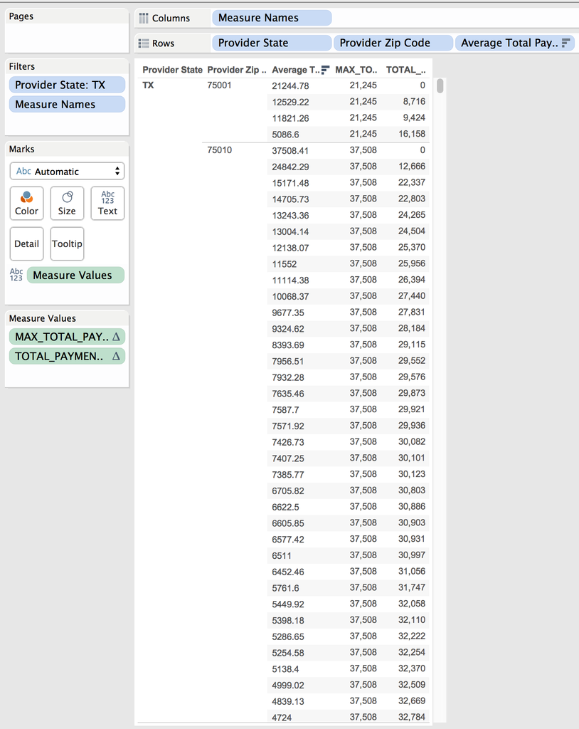

#### SQL

```r
source("../01 SQL Crosstabs/nth.R",echo=TRUE)
```

> nth_df <- data.frame(fromJSON(getURL(URLencode(gsub(“”, + " “,”129.152.144.84:5001/rest/native/?query="SELECT drg_definition, provider_st …. [TRUNCATED]

> kable(head(nth_df))

| DRG_DEFINITION | PROVIDER_STATE | PROVIDER_CITY | AVERAGE_TOTAL_PAYMENTS | MAX_AVERAGE_TOTAL_PAYMENTS |
| --- | --- | --- | --- | --- |
| 069 - TRANSIENT ISCHEMIA | TX | ABILENE | 4365.61 | 4365.61 |
| 069 - TRANSIENT ISCHEMIA | TX | AMARILLO | 4920.60 | 4920.60 |
| 069 - TRANSIENT ISCHEMIA | TX | AMARILLO | 3949.13 | 4920.60 |
| 069 - TRANSIENT ISCHEMIA | TX | ARLINGTON | 4949.05 | 4949.05 |
| 069 - TRANSIENT ISCHEMIA | TX | ARLINGTON | 4274.18 | 4949.05 |
| 069 - TRANSIENT ISCHEMIA | TX | ATHENS | 4415.20 | 4415.20 |

#### Tableau

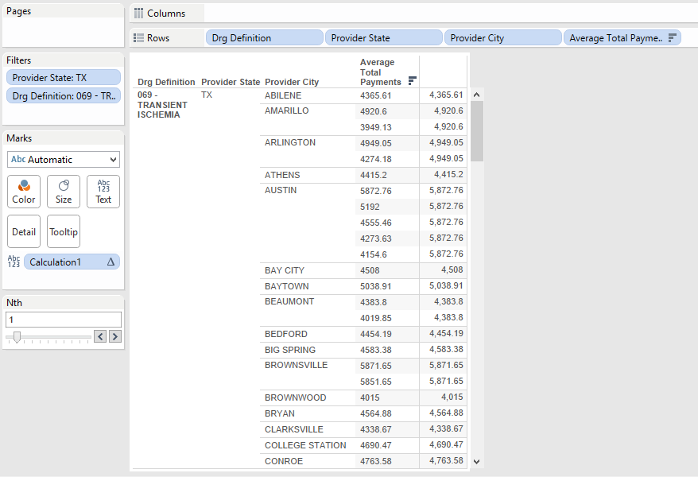

### In this Crosstab, the SQL cumulative distribution function is utilized to return average cost information for central Texas, with cumulative distribution partitioned by city. These results are for records with the drg_definition of ‘885 - PSYCHOSES’

#### SQL

```r
source("../01 SQL Crosstabs/cume_dist.R",echo=TRUE)
```

> cume_df <- data.frame(fromJSON(getURL(URLencode(gsub(“”, + " “,”129.152.144.84:5001/rest/native/?query="SELECT provider_name, provider_ci …. [TRUNCATED]

> kable(head(cume_df))

| PROVIDER_NAME | PROVIDER_CITY | AVERAGE_TOTAL_PAYMENTS | CUME_DIST |
| --- | --- | --- | --- |
| SETON MEDICAL CENTER AUSTIN | AUSTIN | 5155.73 | 1.0 |
| MEDICAL CITY DALLAS HOSPITAL | DALLAS | 5602.20 | 0.5 |
| TEXAS HEALTH PRESBYTERIAN HOSPITAL DALLAS | DALLAS | 6104.08 | 1.0 |
| BAPTIST MEDICAL CENTER | SAN ANTONIO | 5739.57 | 0.2 |
| METHODIST HOSPITAL | SAN ANTONIO | 6107.52 | 0.4 |
| NIX HEALTH CARE SYSTEM | SAN ANTONIO | 6783.01 | 0.6 |

#### Tableau

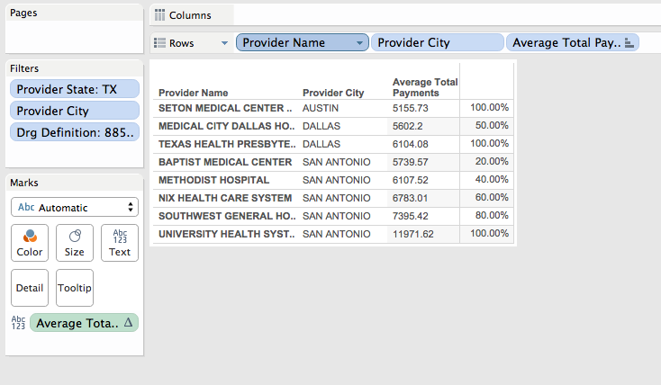